# CASE STUDY: E_COMMERCE DELIVERY

Here we are looking at the data obtained from an online delivery store, that delivers customized apparels to customers. Given various details such as the order details, factory details, expected_delivery_date, we need to predict whether the product would be delivered on time or not.

## IMPORTS

```python
import pandas as pd
from datetime import timedelta
import matplotlib.pyplot as plt
from tqdm import tqdm_notebook as tqdm
import numpy as np
import seaborn as sns
from statsmodels.stats.outliers_influence import variance_inflation_factor
from sklearn.model_selection import train_test_split
from sklearn.linear_model import LogisticRegression
from sklearn.svm import SVC,LinearSVC
from sklearn.metrics import accuracy_score
from sklearn.model_selection import cross_val_score
from sklearn.metrics import confusion_matrix
from  sklearn.preprocessing import StandardScaler
from sklearn.decomposition import PCA
from sklearn.preprocessing import scale
from sklearn.metrics import precision_recall_curve
import matplotlib.pyplot as plt
from sklearn.utils.fixes import signature
from sklearn.metrics import average_precision_score
from sklearn.tree import DecisionTreeClassifier
from sklearn.ensemble import RandomForestClassifier
from sklearn.discriminant_analysis import QuadraticDiscriminantAnalysis
from sklearn.metrics import precision_recall_curve
from sklearn.metrics import roc_curve
%matplotlib inline
```

## READING THE DATA

- **Order ID**
- **Country**
- **Shipping Method**
- **Units per Order**
- **Facility**
- **Product Category**
- **On Sale**
- **Transit days**
- **Datetime Ordered**
- **Datetime Sourced**
- **Datetime Product Ready**
- **Datetime Planned**
- **Deadline Source**
- **Deadline Make**
- **Deadline Deliver**
- **Delivered to Plan**

**The below code reads the data from excel file using python package pandas**

```python
data=pd.read_excel(r"D:\files\5th Sem\MS4110-Introduction to Data Analytics\assignment\CASE STUDY_DATA_LATE DELIVERY ROOT CAUSE.xlsx")
```

**Check the head of the loaded data, and check out its info() and describe() methods.**

```python
data.head()
```

|  | order_id | country | shipping_method | units_per_order | facility | product_category | on_sale | transit_days | datetime_ordered | datetime_sourced | datetime_product_ready | datetime_planned | deadline_source | deadline_make | deadline_deliver | delivered_to_plan |
| --- | --- | --- | --- | --- | --- | --- | --- | --- | --- | --- | --- | --- | --- | --- | --- | --- |
| 0 | E00000001 | UNITED KINGDOM | Ground | 1 | OXFORD | ACCESSORIES | Y | 2 | 2016-07-03 03:07:29 | 2016-07-03 04:09:49 | 2016-07-06 00:59:42 | 2016-07-08 | 1612.0 | 38 | 3 | PASS |
| 1 | E00000002 | FRANCE | Ground | 1 | ANTWERP | JACKETS & VESTS | N | 3 | 2016-07-03 00:08:43 | 2016-07-03 02:16:24 | 2016-07-03 07:17:04 | 2016-07-06 | 531.0 | 8 | 3 | PASS |
| 2 | E00000003 | FRANCE | Ground | 1 | ANTWERP | TOPS | Y | 3 | 2016-07-03 00:36:00 | 2016-07-03 02:16:18 | 2016-07-03 06:16:57 | 2016-07-06 | 504.0 | 8 | 3 | PASS |
| 3 | E00000004 | FRANCE | Ground | 1 | ANTWERP | JACKETS & VESTS | Y | 5 | 2016-07-03 00:47:45 | 2016-07-03 02:16:18 | 2016-07-03 06:16:55 | 2016-07-07 | 492.0 | 8 | 5 | PASS |
| 4 | E00000005 | UNITED KINGDOM | Next Day | 1 | OXFORD | JACKETS & VESTS | Y | 1 | 2016-07-03 03:52:13 | 2016-07-03 07:56:33 | 2016-07-05 08:53:19 | 2016-07-06 | 1567.0 | 6 | 1 | PASS |

**Dimensions of the data**

```python
print(data.shape)
```

```
(79999, 16)
```

**We can see the number of unique categories in the categorical data by using data.describe**

```python
data.describe(include='all')
```

|  | order_id | country | shipping_method | units_per_order | facility | product_category | on_sale | transit_days | datetime_ordered | datetime_sourced | datetime_product_ready | datetime_planned | deadline_source | deadline_make | deadline_deliver | delivered_to_plan |
| --- | --- | --- | --- | --- | --- | --- | --- | --- | --- | --- | --- | --- | --- | --- | --- | --- |
| count | 79999 | 79999 | 79999 | 79999.000000 | 79999 | 79999 | 79999 | 79999.000000 | 79999 | 79999 | 79999 | 79999 | 79464.000000 | 79999.000000 | 79999.000000 | 79999 |
| unique | 79999 | 5 | 4 | NaN | 6 | 3 | 2 | NaN | 78681 | 72611 | 77461 | 127 | NaN | NaN | NaN | 2 |
| top | E00033976 | GERMANY | Ground | NaN | AUGSBURG | JACKETS & VESTS | Y | NaN | 2016-08-20 17:03:18 | 2016-09-16 08:39:53 | 2016-07-11 11:38:10 | 2016-09-30 00:00:00 | NaN | NaN | NaN | PASS |
| freq | 1 | 46259 | 55494 | NaN | 19080 | 48523 | 41168 | NaN | 8 | 6 | 4 | 1539 | NaN | NaN | NaN | 70978 |
| first | NaN | NaN | NaN | NaN | NaN | NaN | NaN | NaN | 2016-07-03 00:08:43 | 2016-07-03 02:16:18 | 2016-07-03 06:16:55 | 2016-07-05 00:00:00 | NaN | NaN | NaN | NaN |
| last | NaN | NaN | NaN | NaN | NaN | NaN | NaN | NaN | 2016-10-21 17:55:30 | 2016-11-10 00:33:50 | 2016-11-10 19:30:18 | 2016-11-17 00:00:00 | NaN | NaN | NaN | NaN |
| mean | NaN | NaN | NaN | 1.040013 | NaN | NaN | NaN | 2.338067 | NaN | NaN | NaN | NaN | 1349.708975 | 41.173127 | 3.450756 | NaN |
| std | NaN | NaN | NaN | 0.466923 | NaN | NaN | NaN | 0.992345 | NaN | NaN | NaN | NaN | 1104.229891 | 25.686936 | 1.617486 | NaN |
| min | NaN | NaN | NaN | 1.000000 | NaN | NaN | NaN | 1.000000 | NaN | NaN | NaN | NaN | 1.000000 | 1.000000 | 1.000000 | NaN |
| 25% | NaN | NaN | NaN | 1.000000 | NaN | NaN | NaN | 2.000000 | NaN | NaN | NaN | NaN | 484.000000 | 23.000000 | 2.000000 | NaN |
| 50% | NaN | NaN | NaN | 1.000000 | NaN | NaN | NaN | 2.000000 | NaN | NaN | NaN | NaN | 1115.000000 | 33.000000 | 3.000000 | NaN |
| 75% | NaN | NaN | NaN | 1.000000 | NaN | NaN | NaN | 3.000000 | NaN | NaN | NaN | NaN | 1600.250000 | 55.000000 | 5.000000 | NaN |
| max | NaN | NaN | NaN | 50.000000 | NaN | NaN | NaN | 8.000000 | NaN | NaN | NaN | NaN | 6392.000000 | 168.000000 | 13.000000 | NaN |

```python
data.info()
```

```
<class 'pandas.core.frame.DataFrame'>
RangeIndex: 79999 entries, 0 to 79998
Data columns (total 16 columns):
order_id                  79999 non-null object
country                   79999 non-null object
shipping_method           79999 non-null object
units_per_order           79999 non-null int64
facility                  79999 non-null object
product_category          79999 non-null object
on_sale                   79999 non-null object
transit_days              79999 non-null int64
datetime_ordered          79999 non-null datetime64[ns]
datetime_sourced          79999 non-null datetime64[ns]
datetime_product_ready    79999 non-null datetime64[ns]
datetime_planned          79999 non-null datetime64[ns]
deadline_source           79464 non-null float64
deadline_make             79999 non-null int64
deadline_deliver          79999 non-null int64
delivered_to_plan         79999 non-null object
dtypes: datetime64[ns](4), float64(1), int64(4), object(7)
memory usage: 9.8+ MB
```

## CREATING NEW COLUMNS THAT RECORD THE TIME INTERVAL BETWEEN DATES

We create new columns to record the time intervals between the carious dates and the time ordered as this is easier to work with and captures the necessary information from this data.**Old variables** are being replaced by **new variables** here.

**Old variables**

- **Datetime Ordered**
- **Datetime Sourced**
- **Datetime Product Ready**
- **Datetime Planned**

**New Variables**

- **Time Sourced**: Time taken to take the product to work station
- **Time Make** : Time taken to make the product at the work station
- **Time Ready**: Total time taken to make the product ready from the time it has been ordered

```python
#converting the given dates to time intervals which ccan be worked with. check the lambda
# function for conversion to seconds minutes or days

data['time_sourced']=(data.datetime_sourced-data.datetime_ordered).map(lambda x:int(x.seconds/(60)))# in minutes
data['time_make']=(data.datetime_product_ready-data.datetime_ordered).map(lambda x: int(x.seconds/(3600))) # in hours
data['time_ready']=(data.datetime_product_ready-data.datetime_ordered).map(lambda x: int(x.days/(1))) # in days
```

## IMPUTING NULL VALUES INTO THE DATA

**Here we check for the null value in the data**

```python
for i in data:
    print(i,data[i].isnull().values.any(),sep='\t\t\t')
```

```
order_id			False
country			False
shipping_method			False
units_per_order			False
facility			False
product_category			False
on_sale			False
transit_days			False
datetime_ordered			False
datetime_sourced			False
datetime_product_ready			False
datetime_planned			False
deadline_source			True
deadline_make			False
deadline_deliver			False
delivered_to_plan			False
time_sourced			False
time_make			False
time_ready			False
```

**We find out that only the deadline source column has null value.The code below is used to find the number of rows which have null values**

```python
data[data.isnull().values].sample()
```

|  | order_id | country | shipping_method | units_per_order | facility | product_category | on_sale | transit_days | datetime_ordered | datetime_sourced | datetime_product_ready | datetime_planned | deadline_source | deadline_make | deadline_deliver | delivered_to_plan | time_sourced | time_make | time_ready |
| --- | --- | --- | --- | --- | --- | --- | --- | --- | --- | --- | --- | --- | --- | --- | --- | --- | --- | --- | --- |
| 16783 | E00016804 | UNITED KINGDOM | Ground | 1 | MANCHESTER | JACKETS & VESTS | N | 1 | 2016-07-28 15:25:07 | 2016-07-28 16:25:06 | 2016-07-29 18:43:19 | 2016-08-02 | NaN | 26 | 3 | PASS | 59 | 3 | 1 |

**535 rows have null columns in the data matrix**

Here we create a new data matrix by the name of **data_corr**. We drop the old variables and introduce the old variables.

```python
data_corr=data;
data_corr=data_corr.drop(['order_id','delivered_to_plan','datetime_ordered','datetime_sourced','datetime_product_ready','datetime_planned'],axis=1)
data_corr.head()
```

|  | country | shipping_method | units_per_order | facility | product_category | on_sale | transit_days | deadline_source | deadline_make | deadline_deliver | time_sourced | time_make | time_ready |
| --- | --- | --- | --- | --- | --- | --- | --- | --- | --- | --- | --- | --- | --- |
| 0 | UNITED KINGDOM | Ground | 1 | OXFORD | ACCESSORIES | Y | 2 | 1612.0 | 38 | 3 | 62 | 21 | 2 |
| 1 | FRANCE | Ground | 1 | ANTWERP | JACKETS & VESTS | N | 3 | 531.0 | 8 | 3 | 127 | 7 | 0 |
| 2 | FRANCE | Ground | 1 | ANTWERP | TOPS | Y | 3 | 504.0 | 8 | 3 | 100 | 5 | 0 |
| 3 | FRANCE | Ground | 1 | ANTWERP | JACKETS & VESTS | Y | 5 | 492.0 | 8 | 5 | 88 | 5 | 0 |
| 4 | UNITED KINGDOM | Next Day | 1 | OXFORD | JACKETS & VESTS | Y | 1 | 1567.0 | 6 | 1 | 244 | 5 | 2 |

```python
print(data_corr.shape)
```

```
(79999, 13)
```

The new matrix: **data_corr** has 13 columns now.

### Creating a dictionary so that we can map the categorical values. Categorical variables are:

- **Country**: UNITED KINGDOM : 0, FRANCE **: 1, GERMANY** : 2**,** SWEDEN**: 3, BELGIUM** : 4
- **Shipping Method** : Ground **: 0,** : Next Day **: 1,** 3-Day**: 2,** 2-Day**: 3
- **Facility**: **OXFORD**: 0, **ANTWERP**: 1, **MANCHESTER**: 2, **AUGSBURG**: 3, **HANOVER**: 4, **EINDHOVEN**: 5
- **Product Category**: **ACCESSORIES**: 0, **JACKETS & VESTS**: 1, **TOPS**: 2
- **On Sale**: **Y**: 0, **N**: 1

```python
col=['country','shipping_method','facility','product_category','on_sale']
tmp=[];
for i,j in enumerate(col):
    a=data_corr[j].unique()
    tmp.append(dict(zip(a,list(range(0,len(a))))))
    print(tmp[i])
    data_corr[j]=data_corr[j].map(tmp[i])
```

```
{'UNITED KINGDOM': 0, 'FRANCE': 1, 'GERMANY': 2, 'SWEDEN': 3, 'BELGIUM': 4}
{'Ground': 0, 'Next Day': 1, '3-Day': 2, '2-Day': 3}
{'OXFORD': 0, 'ANTWERP': 1, 'MANCHESTER': 2, 'AUGSBURG': 3, 'HANOVER': 4, 'EINDHOVEN': 5}
{'ACCESSORIES': 0, 'JACKETS & VESTS': 1, 'TOPS': 2}
{'Y': 0, 'N': 1}
```

```python
data_corr.head()
```

|  | country | shipping_method | units_per_order | facility | product_category | on_sale | transit_days | deadline_source | deadline_make | deadline_deliver | time_sourced | time_make | time_ready |
| --- | --- | --- | --- | --- | --- | --- | --- | --- | --- | --- | --- | --- | --- |
| 0 | 0 | 0 | 1 | 0 | 0 | 0 | 2 | 1612.0 | 38 | 3 | 62 | 21 | 2 |
| 1 | 1 | 0 | 1 | 1 | 1 | 1 | 3 | 531.0 | 8 | 3 | 127 | 7 | 0 |
| 2 | 1 | 0 | 1 | 1 | 2 | 0 | 3 | 504.0 | 8 | 3 | 100 | 5 | 0 |
| 3 | 1 | 0 | 1 | 1 | 1 | 0 | 5 | 492.0 | 8 | 5 | 88 | 5 | 0 |
| 4 | 0 | 1 | 1 | 0 | 1 | 0 | 1 | 1567.0 | 6 | 1 | 244 | 5 | 2 |

**Pushing the column with NaN values:deadline_source to the front for easy matrix manipulation which will be required later**

```python
a=list(data_corr.columns[0:7])
b=list(data_corr.columns[8:13])
c=[data_corr.columns[7]]
print(c+a+b)
data_corr=data_corr[c+a+b]
```

```
['deadline_source', 'country', 'shipping_method', 'units_per_order', 'facility', 'product_category', 'on_sale', 'transit_days', 'deadline_make', 'deadline_deliver', 'time_sourced', 'time_make', 'time_ready']
```

**Printing the columns of the data_corr**

```python
data_corr.columns
```

```
Index(['deadline_source', 'country', 'shipping_method', 'units_per_order',
       'facility', 'product_category', 'on_sale', 'transit_days',
       'deadline_make', 'deadline_deliver', 'time_sourced', 'time_make',
       'time_ready'],
      dtype='object')
```

We find **Mean** of all the variables here

```python
mew=np.mean(data_corr.dropna(),axis=0)#mean
mew
```

```
deadline_source     1349.708975
country                1.301268
shipping_method        0.511703
units_per_order        1.040056
facility               2.629983
product_category       1.241745
on_sale                0.486296
transit_days           2.339512
deadline_make         40.997835
deadline_deliver       3.449562
time_sourced         176.838782
time_make             11.870747
time_ready             0.642064
dtype: float64
```

### Finding the conditional Gaussian Distributions

[figure not shown]

**x_b is a matrix that corresponds to all the columns which originally had NaN values.**

```python
x_b=data_corr[data_corr.isnull().values].iloc[:,1:];
print(x_b.shape)
```

```
(535, 12)
```

### Actual Code for finding the Conditional Gaussian Distributions

**Calculating the mean vector and covariance matrix for data matrix by excluding the NaN values**

```python
mew=np.mean(data_corr.dropna(),axis=0)#mean
sigma=np.cov(data_corr.dropna(),rowvar=0)#covariance matrix
```

**Calculating the mean vector for the two partitions of the columns. Here :**

- a : deadline_source column
- b : rest of the variables

```python
mew_a=mew[0].reshape(1,1)#mean of deadline_source
mew_b=mew[1:].values.reshape(12,1)#remaining means
```

**Calculating separate components of covariance matrix**

```python
np.set_printoptions(suppress=True,precision=3)

#see above image
sigma_aa=sigma[0,0].reshape(1,1)
sigma_bb=sigma[1:,1:].reshape(12,12)
sigma_ab=sigma[0,1:].reshape(1,12)
sigma_ba=sigma[1:,0].reshape(12,1)
```

**mew a|b is the vector which has to be imputed into the deadline_source column**

```python
a= np.tile(mew_a,(535,1))
b=np.matmul(sigma_ab,np.linalg.inv(sigma_bb))
c=np.subtract(x_b,np.tile(mew_b.T,(535,1))).T
d=np.matmul(b,c).T
e=np.add(a,d)
x_a=e

# mew a|b = x_a
```

**Printing mew a|b and sigma_ab , sigma_aa , sigma_bb**

```python
print(sigma_aa.shape,sigma_ab.shape,sigma_ba.shape,sigma_bb.shape,sep='\n')
print(np.matmul(sigma_ab,np.linalg.inv(sigma_bb)).shape)
print(mew_b.shape,mew_a.shape,mew_a)
print(x_a.shape)
print(np.mean(x_a))
print(mew[0])# old mean for deadline_source
```

```
(1, 1)
(1, 12)
(12, 1)
(12, 12)
(1, 12)
(12, 1) (1, 1) [[1349.709]]
(535, 1)
1998.0007634030123
1349.7089751333938
```

```python
print(sigma.shape)
```

```
(13, 13)
```

**Replacing data_corr NaN values**

```python
data_corr.iloc[list(data_corr[data_corr.isnull().values].index),[0]]=x_a
```

```python
data_corr.head()
```

|  | deadline_source | country | shipping_method | units_per_order | facility | product_category | on_sale | transit_days | deadline_make | deadline_deliver | time_sourced | time_make | time_ready |
| --- | --- | --- | --- | --- | --- | --- | --- | --- | --- | --- | --- | --- | --- |
| 0 | 1612.0 | 0 | 0 | 1 | 0 | 0 | 0 | 2 | 38 | 3 | 62 | 21 | 2 |
| 1 | 531.0 | 1 | 0 | 1 | 1 | 1 | 1 | 3 | 8 | 3 | 127 | 7 | 0 |
| 2 | 504.0 | 1 | 0 | 1 | 1 | 2 | 0 | 3 | 8 | 3 | 100 | 5 | 0 |
| 3 | 492.0 | 1 | 0 | 1 | 1 | 1 | 0 | 5 | 8 | 5 | 88 | 5 | 0 |
| 4 | 1567.0 | 0 | 1 | 1 | 0 | 1 | 0 | 1 | 6 | 1 | 244 | 5 | 2 |

```python
np.mean(data_corr.deadline_source) # new mean for deadline_source
```

```
1354.044480661266
```

### Plotting Heatmaps

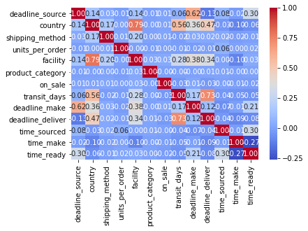

```python
import seaborn as sns

#collinearity heatmap
sns.heatmap(data_corr.corr(),annot=True,fmt=".2f",cmap="coolwarm")
```

```python
y=data.delivered_to_plan;
```

```python
y=y.map({'PASS':1,'FAIL':0})
print(y.unique())
```

```
[1 0]
```

### Using PCA on the dataset

Here we apply PCA on the data set to receive new PCA components which will replace the old variables.

```python
def PCAconv(data,n=13):
    tmp=StandardScaler().fit_transform(data.values)
    pca = PCA(n_components=n)
    tmp.shape
    # np.isnan(np.min(tmp))
    principalComponents = pca.fit_transform(tmp)

    X = pd.DataFrame(data = principalComponents)
    X.shape
    return(X)


X= PCAconv(data_corr,13)
```

**The new PCA components generated have variance in decreasing order which means that the amount of information contained in these components decreases.**

```python
X.var()
```

```
0     2.842806
1     1.814210
2     1.262682
3     1.125505
4     1.024044
5     1.003114
6     0.983244
7     0.941201
8     0.737996
9     0.528967
10    0.366693
11    0.237545
12    0.132156
dtype: float64
```

```python
X.describe()
```

|  | 0 | 1 | 2 | 3 | 4 | 5 | 6 | 7 | 8 | 9 | 10 | 11 | 12 |
| --- | --- | --- | --- | --- | --- | --- | --- | --- | --- | --- | --- | --- | --- |
| count | 7.999900e+04 | 7.999900e+04 | 7.999900e+04 | 7.999900e+04 | 7.999900e+04 | 7.999900e+04 | 79999.000000 | 7.999900e+04 | 7.999900e+04 | 7.999900e+04 | 7.999900e+04 | 7.999900e+04 | 7.999900e+04 |
| mean | 6.821296e-17 | 5.684413e-17 | 1.421103e-18 | -3.126427e-17 | -2.113891e-17 | 7.816068e-17 | 0.000000 | -1.136883e-17 | -6.252854e-17 | -9.947723e-18 | -2.415876e-17 | 2.113891e-17 | -8.526619e-18 |
| std | 1.686062e+00 | 1.346926e+00 | 1.123691e+00 | 1.060898e+00 | 1.011951e+00 | 1.001556e+00 | 0.991586 | 9.701554e-01 | 8.590669e-01 | 7.273014e-01 | 6.055515e-01 | 4.873854e-01 | 3.635330e-01 |
| min | -4.012110e+00 | -4.692538e+00 | -3.760563e+00 | -4.685483e+00 | -2.906799e+00 | -2.670547e+00 | -3.050498 | -4.241392e+00 | -3.349203e+00 | -3.133034e+00 | -4.378589e+00 | -2.660851e+00 | -2.207413e+00 |
| 25% | -1.526081e+00 | -9.649551e-01 | -7.310645e-01 | -7.014911e-01 | -5.788722e-01 | -6.274957e-01 | -0.733016 | -4.287107e-01 | -6.209268e-01 | -3.487734e-01 | -2.991006e-01 | -3.326681e-01 | -2.602908e-01 |
| 50% | 4.061371e-01 | -2.341790e-01 | -9.059433e-02 | -1.711929e-01 | -5.201024e-02 | -4.629489e-02 | -0.003554 | 4.473363e-02 | -1.587894e-02 | 2.277040e-02 | 5.880763e-02 | -2.564888e-02 | 1.891891e-02 |
| 75% | 1.353502e+00 | 8.017548e-01 | 5.864862e-01 | 6.410535e-01 | 4.818216e-01 | 7.770546e-01 | 0.733615 | 5.130330e-01 | 6.293135e-01 | 3.232010e-01 | 4.090364e-01 | 3.375253e-01 | 2.430523e-01 |
| max | 6.909642e+00 | 2.104147e+01 | 1.990756e+01 | 2.375381e+01 | 7.064605e+01 | 6.744086e+00 | 36.948169 | 6.148510e+01 | 4.916760e+00 | 2.502874e+01 | 5.399859e+00 | 3.021805e+00 | 3.424030e+00 |

**Splitting the data matrix into test and training**

```python
from sklearn.model_selection import train_test_split
X_train, X_test, y_train, y_test = train_test_split(X, y, test_size = 0.2)
print(X_train.shape, X_test.shape,y_train.shape, y_test.shape)
```

```
(63999, 13) (16000, 13) (63999,) (16000,)
```

```python
print(y_train.head())
print(X_train.shape)
X_train.head()
```

```
23434    1
50738    1
5264     1
78245    1
36753    1
Name: delivered_to_plan, dtype: int64
(63999, 13)
```

|  | 0 | 1 | 2 | 3 | 4 | 5 | 6 | 7 | 8 | 9 | 10 | 11 | 12 |
| --- | --- | --- | --- | --- | --- | --- | --- | --- | --- | --- | --- | --- | --- |
| 23434 | 1.327005 | 2.086484 | -1.327671 | -0.707027 | 0.782229 | 1.377934 | -1.552958 | 0.438814 | -1.245893 | -0.180534 | 0.331772 | 0.235411 | -0.285575 |
| 50738 | -1.388821 | -0.372425 | 1.197259 | -0.838448 | -1.144522 | 1.296845 | 0.573664 | 0.564190 | 1.059245 | -0.191873 | -0.600723 | 0.639083 | 0.301069 |
| 5264 | -2.370972 | 0.688549 | 0.013940 | -0.087828 | 0.314987 | 1.464200 | -2.074652 | 0.537084 | 0.672686 | -0.099732 | -0.228614 | 0.093396 | 0.270859 |
| 78245 | 1.313097 | -1.564764 | 0.612151 | -0.068120 | -0.323368 | 0.950377 | 0.775877 | -0.411472 | -0.482846 | -0.000253 | -0.246818 | 0.545150 | 0.100609 |
| 36753 | 2.182518 | -0.137751 | -1.922196 | 1.004177 | 0.482621 | 0.398032 | 0.285522 | -0.861113 | 1.186950 | 0.519652 | -1.199585 | -0.468567 | -0.102272 |

### DOWNSAMPLING THE DATA

```python
X_train.join(y_train).head()
```

|  | 0 | 1 | 2 | 3 | 4 | 5 | 6 | 7 | 8 | 9 | 10 | 11 | 12 | delivered_to_plan |
| --- | --- | --- | --- | --- | --- | --- | --- | --- | --- | --- | --- | --- | --- | --- |
| 23434 | 1.327005 | 2.086484 | -1.327671 | -0.707027 | 0.782229 | 1.377934 | -1.552958 | 0.438814 | -1.245893 | -0.180534 | 0.331772 | 0.235411 | -0.285575 | 1 |
| 50738 | -1.388821 | -0.372425 | 1.197259 | -0.838448 | -1.144522 | 1.296845 | 0.573664 | 0.564190 | 1.059245 | -0.191873 | -0.600723 | 0.639083 | 0.301069 | 1 |
| 5264 | -2.370972 | 0.688549 | 0.013940 | -0.087828 | 0.314987 | 1.464200 | -2.074652 | 0.537084 | 0.672686 | -0.099732 | -0.228614 | 0.093396 | 0.270859 | 1 |
| 78245 | 1.313097 | -1.564764 | 0.612151 | -0.068120 | -0.323368 | 0.950377 | 0.775877 | -0.411472 | -0.482846 | -0.000253 | -0.246818 | 0.545150 | 0.100609 | 1 |
| 36753 | 2.182518 | -0.137751 | -1.922196 | 1.004177 | 0.482621 | 0.398032 | 0.285522 | -0.861113 | 1.186950 | 0.519652 | -1.199585 | -0.468567 | -0.102272 | 1 |

**Original dataset has the problem of imbalanced class**

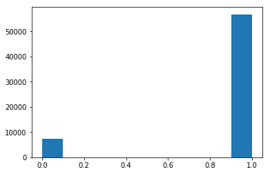

```python
plt.hist(y_train)
```

```python
a=y[y==1].shape[0]
b=y[y==0].shape[0]
print(a,b)
fraction_a = a/(a+b)
fraction_b = b/(a+b)
print(fraction_a)
print(fraction_b)
```

```
70978 9021
0.8872360904511306
0.11276390954886936
```

**The original dataset has 1:9 ratio for fail:pass orders. This will create a bias in prediction towards pass. So we downsample the data in the ratio of 60:40 for pass:fail. This way we are trying to reduce the bias while training the model.**

|  | 0 | 1 | 2 | 3 | 4 | 5 | 6 | 7 | 8 | 9 | 10 | 11 | 12 |
| --- | --- | --- | --- | --- | --- | --- | --- | --- | --- | --- | --- | --- | --- |
| count | 18097.000000 | 18097.000000 | 18097.000000 | 18097.000000 | 18097.000000 | 18097.000000 | 18097.000000 | 18097.000000 | 18097.000000 | 18097.000000 | 18097.000000 | 18097.000000 | 18097.000000 |
| mean | 0.013375 | 0.064632 | 0.064679 | 0.077723 | 0.018427 | -0.002268 | -0.001441 | -0.030297 | 0.005372 | 0.034487 | -0.003018 | -0.009421 | 0.015763 |
| std | 1.657060 | 1.396904 | 1.154203 | 1.120843 | 1.086323 | 0.999360 | 1.018861 | 1.031699 | 0.891469 | 0.746060 | 0.639930 | 0.510279 | 0.373523 |
| min | -3.390772 | -4.302059 | -3.760563 | -4.264042 | -2.333687 | -2.633649 | -2.981295 | -4.241392 | -3.165951 | -3.098033 | -4.378589 | -2.484177 | -2.207413 |
| 25% | -1.422753 | -0.968758 | -0.687474 | -0.675079 | -0.583700 | -0.626397 | -0.737231 | -0.452475 | -0.637799 | -0.355567 | -0.318842 | -0.339170 | -0.248231 |
| 50% | 0.366417 | -0.174663 | -0.041855 | -0.099777 | -0.048069 | -0.050693 | -0.009585 | 0.033845 | 0.020694 | 0.040966 | 0.062402 | -0.033537 | 0.027276 |
| 75% | 1.341414 | 0.961383 | 0.668889 | 0.763093 | 0.478612 | 0.776752 | 0.733505 | 0.482753 | 0.648054 | 0.364443 | 0.436831 | 0.335240 | 0.259329 |
| max | 6.309941 | 16.339986 | 13.451623 | 14.731798 | 41.173338 | 6.509879 | 21.883286 | 36.380268 | 4.445655 | 22.051712 | 3.603027 | 2.983799 | 2.535463 |

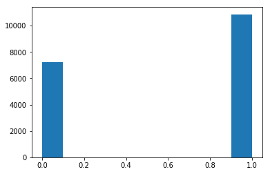

```python
tmp=X_train.join(y_train)
b=tmp[tmp.delivered_to_plan==0]#.sample(n=3000,random_state=4)
a=tmp[tmp.delivered_to_plan==1].sample(n=int(b.shape[0]*(0.6/0.4)),random_state=4)
c=a.append(b)
X_train=c[c.columns[0:(c.shape[1]-1)]]
y_train=c[c.columns[c.shape[1]-1]]
plt.hist(y_train)
X_train.describe()
```

**The above downsampled dataset has 60:40 as the ratio for pass and fail orders**

Now we find out the **accuracy** of the model. This turns out to be roughly **0.84**

```python
from sklearn.linear_model import LogisticRegression
classifier = LogisticRegression(random_state=0, solver='lbfgs',
                         multi_class='multinomial').fit(X_train, y_train)
y_pred = classifier.predict(X_test)
print(accuracy_score(y_test, y_pred))
```

```
0.8418125
```

**Cross Validation score is 0.885** which is quite close to the **accuracy(0.84)**

```python
scores = cross_val_score(classifier, X, y, cv=5,verbose=1)
mean = np.mean(scores)
print(scores)
print(mean)
```

```
[Parallel(n_jobs=1)]: Done   5 out of   5 | elapsed:    2.1s finished
```

```
[0.884 0.886 0.886 0.886 0.886]
0.8854110966060492
```

### Using PCA to create 13 different models having PCA componets ranging from 1-13 and comparing their efficiencies.

One function PCS_c is defined which calculates **accuracy on test data** , **5-fold cross validation score** , **true positive rate** , **false positive rate** and **Precision**

```python
def PCA_c(data,n=13):
    tmp=StandardScaler().fit_transform(data.values)
    pca = PCA(n_components=n)
    tmp.shape
    principalComponents = pca.fit_transform(tmp)
    X = pd.DataFrame(data = principalComponents)
    X_train, X_test, y_train, y_test = train_test_split(X, y, test_size = 0.2)
    X_train.join(y_train).head()
    tmp=X_train.join(y_train)
    b=tmp[tmp.delivered_to_plan==0]#.sample(n=3000,random_state=4)
    a=tmp[tmp.delivered_to_plan==1].sample(n=int(b.shape[0]*(0.6/0.4)),random_state=4)
    c=a.append(b)
    X_train=c[c.columns[0:(c.shape[1]-1)]]
    y_train=c[c.columns[c.shape[1]-1]]
    classifier = LogisticRegression(random_state=0, solver='lbfgs',
                             multi_class='multinomial').fit(X_train, y_train)
    y_pred = classifier.predict(X_test)
    scores = cross_val_score(classifier, X, y, cv=5,verbose=1)
    mean = np.mean(scores)
    #print(scores)
    y_pred = classifier.predict(X_test)
    tn, fp, fn, tp = confusion_matrix(y_test, y_pred).ravel()
    true_positive_rate = tp/(tp+fn)
    false_positive_rate = fp/(tn+fp)
    precision = tp/(tp+fp)
    print("accuracy on test data" , accuracy_score(y_test, y_pred))
    print("5-fold cross validation score",mean)
    print("true positive rate",true_positive_rate)
    print("false positive rate",false_positive_rate)
    print("Precision",precision)
    print(confusion_matrix(y_test, y_pred))

    return (accuracy_score(y_test, y_pred),mean,true_positive_rate,false_positive_rate,precision)


#FPR IS TOO HIGH
#Precision is high due to class imbalance
```

**The loop calculates cross validation, accuracy, true positive rate , false positive rate and precision for 13 different models that we created using PCA. This will help us in understanding the variation of all the above mentioned metrics.**

```python
cv=np.zeros(13)
accuracy=np.zeros(13)
tpr=np.zeros(13)
fpr=np.zeros(13)
precision_rate=np.zeros(13)

for i in range(1,14):
    accuracy[i-1],cv[i-1],tpr[i-1],fpr[i-1],precision_rate[i-1]=PCA_c(data_corr,i)
```

```
[Parallel(n_jobs=1)]: Done   5 out of   5 | elapsed:    1.3s finished
```

```
accuracy on test data 0.88925
5-fold cross validation score 0.8872360911419378
true positive rate 1.0
false positive rate 1.0
Precision 0.88925
[[    0  1772]
 [    0 14228]]
```

```
[Parallel(n_jobs=1)]: Done   5 out of   5 | elapsed:    1.0s finished
```

```
accuracy on test data 0.88225
5-fold cross validation score 0.8871985927043402
true positive rate 0.9933784164553395
false positive rate 0.9922394678492239
Precision 0.8873647118046816
[[   14  1790]
 [   94 14102]]
```

```
[Parallel(n_jobs=1)]: Done   5 out of   5 | elapsed:    1.3s finished
```

```
accuracy on test data 0.8621875
5-fold cross validation score 0.8870485934852483
true positive rate 0.9593919346892814
false positive rate 0.9089893914014517
Precision 0.8933158584534732
[[  163  1628]
 [  577 13632]]
```

```
[Parallel(n_jobs=1)]: Done   5 out of   5 | elapsed:    1.1s finished
```

```
accuracy on test data 0.83025
5-fold cross validation score 0.8869360934848578
true positive rate 0.9160014129282938
false positive rate 0.8276422764227642
Precision 0.8946387911405506
[[  318  1527]
 [ 1189 12966]]
```

```
[Parallel(n_jobs=1)]: Done   5 out of   5 | elapsed:    1.0s finished
```

```
accuracy on test data 0.837625
5-fold cross validation score 0.8869860950474553
true positive rate 0.9248432767486089
false positive rate 0.8491403216860788
Precision 0.8955732896801036
[[  272  1531]
 [ 1067 13130]]
```

```
[Parallel(n_jobs=1)]: Done   5 out of   5 | elapsed:    1.0s finished
```

```
accuracy on test data 0.83125
5-fold cross validation score 0.8869735942661565
true positive rate 0.9213785294742056
false positive rate 0.850187265917603
Precision 0.8912314326784858
[[  280  1589]
 [ 1111 13020]]
```

```
[Parallel(n_jobs=1)]: Done   5 out of   5 | elapsed:    0.9s finished
```

```
accuracy on test data 0.837875
5-fold cross validation score 0.8869610950474554
true positive rate 0.9256723371214794
false positive rate 0.8406983087834151
Precision 0.894848174684408
[[  292  1541]
 [ 1053 13114]]
```

```
[Parallel(n_jobs=1)]: Done   5 out of   5 | elapsed:    1.3s finished
```

```
accuracy on test data 0.8351875
5-fold cross validation score 0.8869735966100529
true positive rate 0.922647640576434
false positive rate 0.8362255965292842
Precision 0.8944052591933165
[[  302  1542]
 [ 1095 13061]]
```

```
[Parallel(n_jobs=1)]: Done   5 out of   5 | elapsed:    1.2s finished
```

```
accuracy on test data 0.8393125
5-fold cross validation score 0.8869735958288519
true positive rate 0.919358228823653
false positive rate 0.8222350897510133
Precision 0.9023518085545317
[[  307  1420]
 [ 1151 13122]]
```

```
[Parallel(n_jobs=1)]: Done   5 out of   5 | elapsed:    1.2s finished
```

```
accuracy on test data 0.85025
5-fold cross validation score 0.8857235903568303
true positive rate 0.9355613650816081
false positive rate 0.8034650785056849
Precision 0.8992190152801358
[[  363  1484]
 [  912 13241]]
```

```
[Parallel(n_jobs=1)]: Done   5 out of   5 | elapsed:    1.3s finished
```

```
accuracy on test data 0.8516875
5-fold cross validation score 0.8857235942630316
true positive rate 0.9362994350282486
false positive rate 0.7994565217391304
Precision 0.9001289972163758
[[  369  1471]
 [  902 13258]]
```

```
[Parallel(n_jobs=1)]: Done   5 out of   5 | elapsed:    2.0s finished
```

```
accuracy on test data 0.8333125
5-fold cross validation score 0.8856485934816352
true positive rate 0.9144978783592645
false positive rate 0.7838709677419354
Precision 0.8986725971228021
[[  402  1458]
 [ 1209 12931]]
```

```
[Parallel(n_jobs=1)]: Done   5 out of   5 | elapsed:    3.4s finished
```

```
accuracy on test data 0.8431875
5-fold cross validation score 0.8854110966060492
true positive rate 0.92010128006752
false positive rate 0.7704826038159371
Precision 0.9050155655482532
[[  409  1373]
 [ 1136 13082]]
```

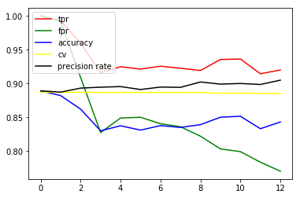

```python
plt.gca().set_color_cycle(['red', 'green', 'blue', 'yellow','black'])

plt.plot(tpr)
plt.plot(fpr)
plt.plot(accuracy)
plt.plot(cv)
plt.plot(precision_rate)

plt.legend(['tpr', 'fpr', 'accuracy', 'cv','precision rate'], loc='upper left')
```

The above graph shows us that the false positive rate decreases drastically as we increase the number of PCA components. While other metrics donot change very drastically. **Hence the best option here would be to retain the number of PCA components as 13.**

### PLOTTING ROC CURVE

Function for plotting the ROC curve

```python
def plot_roc_curve(fpr, tpr, label=None):
    """
    The ROC curve, modified from
    Hands-On Machine learning with Scikit-Learn and TensorFlow; p.91
    """
    plt.figure(figsize=(8,8))
    plt.title('ROC Curve')
    plt.plot(fpr, tpr, linewidth=2, label=label)
    plt.plot([0, 1], [0, 1], 'k--')
    plt.axis([-0.005, 1, 0, 1.005])
    plt.xticks(np.arange(0,1, 0.05), rotation=90)
    plt.xlabel("False Positive Rate")
    plt.ylabel("True Positive Rate (Recall)")
    plt.legend(loc='best')
```

#### Comparing 4 different classifiers "Decision Tree" , "Random Forest", "QDA" , 'Logistic Regression'

```
[Parallel(n_jobs=1)]: Done   1 out of   1 | elapsed:    0.0s finished
No handles with labels found to put in legend.
```

```
0.9165505369292565
Decision Tree acc sc 0.7465625
Decision Tree cross val 0.8850235577764445
[[  764  1018]
 [ 3037 11181]]
Average precision-recall score: 0.91
```

```
No handles with labels found to put in legend.
```

```
0.9020542427497314
Random Forest acc sc 0.86
Random Forest cross val 0.8872360905897647
[[  323  1459]
 [  781 13437]]
Average precision-recall score: 0.90
```

```
No handles with labels found to put in legend.
```

```
0.9037653925546302
QDA acc sc 0.8204375
QDA cross val 0.8664733377709443
[[  430  1352]
 [ 1521 12697]]
Average precision-recall score: 0.90
```

```
[Parallel(n_jobs=1)]: Done   1 out of   1 | elapsed:    0.0s finished
[Parallel(n_jobs=1)]: Done   1 out of   1 | elapsed:    0.4s finished
[Parallel(n_jobs=1)]: Done   1 out of   1 | elapsed:    0.3s finished
No handles with labels found to put in legend.
```

```
0.9042545831892079
Logistic Regression acc sc 0.8418125
Logistic Regression cross val 0.885248573401835
[[  398  1384]
 [ 1147 13071]]
Average precision-recall score: 0.90
```

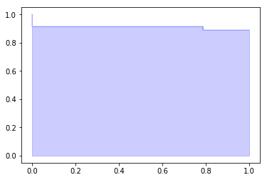

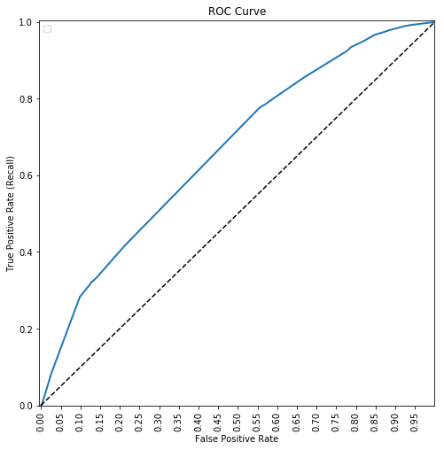

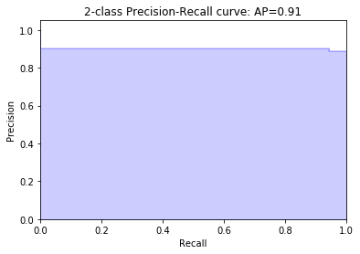

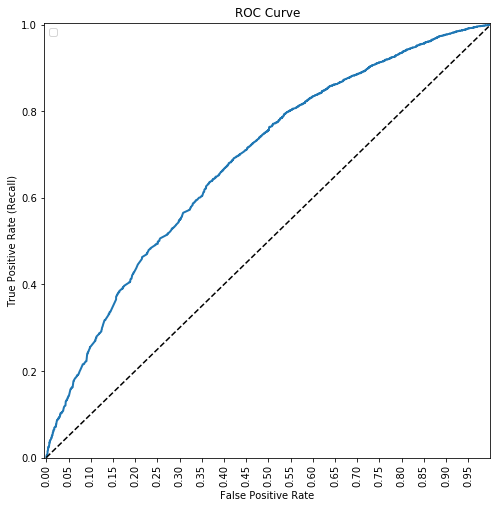

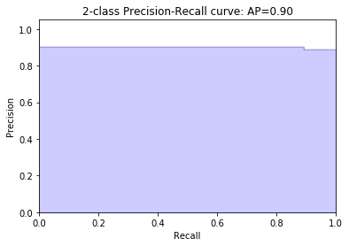

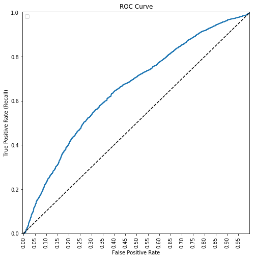

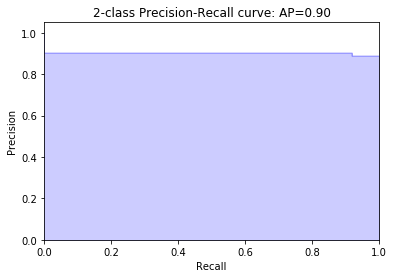

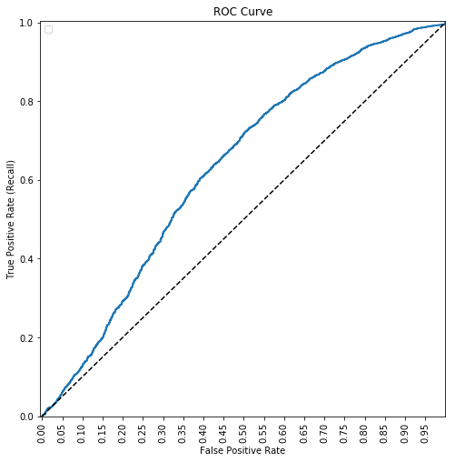

[figure not shown]

```python
from sklearn.metrics import roc_curve
accuracy=[]

classifiers = [
    DecisionTreeClassifier(max_depth=5),
    RandomForestClassifier(max_depth=5, n_estimators=10, max_features=1),
    QuadraticDiscriminantAnalysis(),
    LogisticRegression(random_state=0, solver='lbfgs',
                         multi_class='multinomial',verbose=1).fit(X_train, y_train)]
names = ["Decision Tree", "Random Forest", "QDA",'Logistic Regression']

for name, classifier in zip(names, classifiers):
    classifier.fit(X_train, y_train)
#     scores = cross_val_score(classifier, X, y, cv=5,verbose=1)
    y_pred = classifier.predict(X_test)


    scores = cross_val_score(classifier, X, y, cv=2,verbose=0)
    precision, recall, _ = precision_recall_curve(y_test, y_pred)

    # In matplotlib < 1.5, plt.fill_between does not have a 'step' argument
    step_kwargs = ({'step': 'post'}
                   if 'step' in signature(plt.fill_between).parameters
                   else {})
    plt.step(recall, precision, color='b', alpha=0.2,
             where='post')
    plt.fill_between(recall, precision, alpha=0.2, color='b', **step_kwargs)
    average_precision = average_precision_score(y_test, y_pred)
    tn, fp, fn, tp = confusion_matrix(y_test, y_pred).ravel()
    precision = tp/(tp+fp)
    y_pred_ = classifier.predict_proba(X_test.values)
    fpr,tpr,auc_scores=roc_curve(y_test,y_pred_[:,1])
    plot_roc_curve(fpr,tpr)
    accuracy.append(accuracy_score(y_test, y_pred))
    print(precision)
    print(name,'acc sc',accuracy_score(y_test, y_pred))
    print(name,'cross val',np.mean(scores))
    print(confusion_matrix(y_test, y_pred))
    print('Average precision-recall score: {0:0.2f}'.format(
          average_precision),end='\n\n')

    plt.figure()
    plt.xlabel('Recall')
    plt.ylabel('Precision')
    plt.ylim([0.0, 1.05])
    plt.xlim([0.0, 1.0])
    plt.title('2-class Precision-Recall curve: AP={0:0.2f}'.format(
              average_precision))
```

```python
accuracy
```

```
[0.7465625, 0.86, 0.8204375, 0.8418125]
```

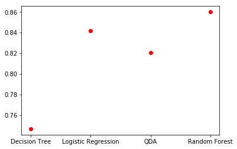

```python
plt.plot(names,accuracy,  'ro')
```

### FINAL CLASSIFIER: RANDOM FOREST

```
[Parallel(n_jobs=1)]: Done   5 out of   5 | elapsed:    3.6s finished
```

```
Confusion Matrix [[  299  1483]
 [  651 13567]]
Accuracy Score 0.866625
```

```
No handles with labels found to put in legend.
```

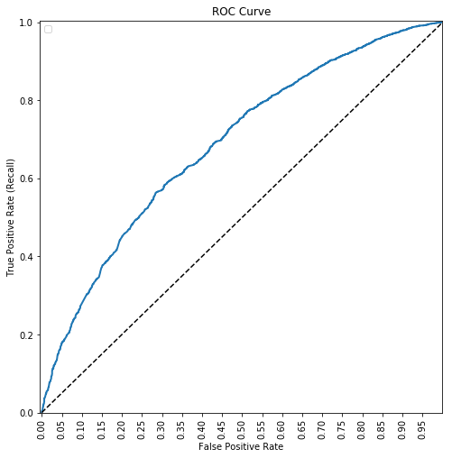

```python
        from sklearn.metrics import roc_curve
        classifier = RandomForestClassifier(max_depth=5, n_estimators=10, max_features=1)
        classifier.fit(X_train, y_train)
        scores = cross_val_score(classifier, X, y, cv=5,verbose=1)
        y_pred = classifier.predict(X_test)

        tn, fp, fn, tp = confusion_matrix(y_test, y_pred).ravel()
        precision = tp/(tp+fp)
        fpr,tpr,auc_scores=roc_curve(y_test,y_pred_[:,1])
        y_pred_ = classifier.predict_proba(X_test.values)
        # print(y_pred_)
        fpr,tpr,auc_scores=roc_curve(y_test,y_pred_[:,1])
        # print(fpr,tpr,auc_scores)
        print('Confusion Matrix',confusion_matrix(y_test, y_pred))
        print('Accuracy Score',accuracy_score(y_test, y_pred))

        plot_roc_curve(fpr,tpr)
        # plt.savefig(r'C:\Users\Aashish\Desktop\test.png')
```

```python
from sklearn.externals import joblib
joblib.dump(classifier,'final.joblib')
```

```
['final.joblib']
```